# Interpretable ML

Alexander McLain

2025-11-11

# 1 Overview

This notebook demonstrates **interpretable machine learning** methods on a classic public-health dataset: **Pima Indians Diabetes**. We will:

- Prepare data (imputation, scaling)
- Fit a **Random Forest** classifier (primary model) and a **Logistic Regression** baseline
- Evaluate discrimination and calibration
- Explain the model with:
  - **Variable Importance (permutation)**
  - **Partial Dependence Plots (PDPs)**
  - **Accumulated Local Effects (ALE)**
  - **SHAP values** (local + global summaries)
  - **LIME** (local surrogate explanations)

We use `tidymodels` for modeling and `vip`, `pdp`, `iml`/`fastshap`, and `lime` for interpretability.

# 2 Packages

```r
# Core modeling
library(tidymodels)     # rsample, recipes, parsnip, workflows, tune, yardstick
library(tidyverse)
library(pROC)
# Data
library(mlbench)        # PimaIndiansDiabetes2
# Interpretability
library(vip)            # variable importance + handy plots
library(pdp)            # partial dependence
library(ALEPlot)        # ALE for classical interface
library(iml)            # model-agnostic interface (PDP/ALE/SHAP)
library(fastshap)       # fast SHAP approximations
library(lime)           # LIME local explanations
# Misc
library(ranger)         # Fast implementation of random forests
library(kableExtra)
kbl2 <- function(x, ...) kable(x, align = "lrrrrrr", ...) %>% kable_styling(full_width = FALSE)
```

# 3 Data: Pima Indians Diabetes

```r
data(PimaIndiansDiabetes2, package = "mlbench")
df <- PimaIndiansDiabetes2 %>%
  as_tibble()

glimpse(df)
```

```
## Rows: 768
## Columns: 9
## $ pregnant <dbl> 6, 1, 8, 1, 0, 5, 3, 10, 2, 8, 4, 10, 10, 1, 5, 7, 0, 7, 1, 1…
## $ glucose  <dbl> 148, 85, 183, 89, 137, 116, 78, 115, 197, 125, 110, 168, 139,…
## $ pressure <dbl> 72, 66, 64, 66, 40, 74, 50, NA, 70, 96, 92, 74, 80, 60, 72, N…
## $ triceps  <dbl> 35, 29, NA, 23, 35, NA, 32, NA, 45, NA, NA, NA, NA, 23, 19, N…
## $ insulin  <dbl> NA, NA, NA, 94, 168, NA, 88, NA, 543, NA, NA, NA, NA, 846, 17…
## $ mass     <dbl> 33.6, 26.6, 23.3, 28.1, 43.1, 25.6, 31.0, 35.3, 30.5, NA, 37.…
## $ pedigree <dbl> 0.627, 0.351, 0.672, 0.167, 2.288, 0.201, 0.248, 0.134, 0.158…
## $ age      <dbl> 50, 31, 32, 21, 33, 30, 26, 29, 53, 54, 30, 34, 57, 59, 51, 3…
## $ diabetes <fct> pos, neg, pos, neg, pos, neg, pos, neg, pos, pos, neg, pos, n…
```

```r
summary(df$diabetes)
```

```
## neg pos
## 500 268
```

**Outcome:** `diabetes` (factor: `"pos"` vs `"neg"`).  
**Predictors:**

- **pregnant**: Number of times pregnant
- **glucose**: Plasma glucose concentration (glucose tolerance test)
- **pressure**: Diastolic blood pressure (mm Hg)
- **triceps**: Triceps skin fold thickness (mm)
- **insulin**: 2-Hour serum insulin (mu U/ml)
- **mass**: Body mass index
- **pedigree**: Diabetes pedigree function
- **age**: Age (years)
- **diabetes**: Class variable (test for diabetes)

# 4 Train/Test Split and Preprocessing

```r
set.seed(735)
split <- initial_split(df, prop = 0.75, strata = diabetes)
train <- training(split)
test  <- testing(split)

# Recipe: median imputation for numeric; mode for nominal; standardization
rec <- recipe(diabetes ~ ., data = train) %>%
  step_impute_median(all_numeric_predictors()) %>%
  step_impute_mode(all_nominal_predictors()) %>%
  step_normalize(all_numeric_predictors())

prep_rec <- prep(rec)
train_baked <- bake(prep_rec, new_data = train)
test_baked  <- bake(prep_rec, new_data = test)
```

# 5 Models

We fit a **Random Forest** (primary ML model) with basic tuning and a **Logistic Regression** baseline.

```r
set.seed(735)

# Random Forest (tuned mtry, trees fixed moderate)
rf_spec <- rand_forest(mtry = tune(), trees = 1000, min_n = 5) %>%
  set_engine("ranger", importance = "permutation", probability = TRUE) %>%
  set_mode("classification")

log_spec <- logistic_reg(penalty = 0, mixture = 1) %>%
  set_engine("glm")

wf_rf  <- workflow() %>% add_model(rf_spec)  %>% add_recipe(rec)
wf_log <- workflow() %>% add_model(log_spec) %>% add_recipe(rec)

# 5-fold CV
set.seed(735)
folds <- vfold_cv(train, v = 5, strata = diabetes)

grid <- grid_regular(mtry(range = c(2L, ncol(train) - 1L)), levels = 5)

rf_tuned <- tune_grid(
  wf_rf,
  resamples = folds,
  grid = grid,
  metrics = metric_set(roc_auc, pr_auc, accuracy, kap)
)

show_best(rf_tuned, metric = "roc_auc", n = 3)
```

```
## # A tibble: 3 × 7
##    mtry .metric .estimator  mean     n std_err .config
##   <int> <chr>   <chr>      <dbl> <int>   <dbl> <chr>
## 1     2 roc_auc binary     0.820     5 0.00519 pre0_mod1_post0
## 2     3 roc_auc binary     0.816     5 0.00369 pre0_mod2_post0
## 3     6 roc_auc binary     0.814     5 0.00635 pre0_mod4_post0
```

```r
best_params <- select_best(rf_tuned, metric = "roc_auc")
rf_final <- finalize_workflow(wf_rf, best_params)

# Fit final models on training data
fit_rf  <- fit(rf_final, data = train)
fit_log <- fit(wf_log,  data = train)
```

# 6 Performance on Test Set

```r
pred_rf  <- predict(fit_rf,  test, type = "prob") %>% bind_cols(predict(fit_rf,  test)) %>% bind_cols(test %>% select(diabetes))
pred_log <- predict(fit_log, test, type = "prob") %>% bind_cols(predict(fit_log, test)) %>% bind_cols(test %>% select(diabetes))

# ROC AUC / PR AUC / Accuracy
metrics_rf  <- pred_rf  %>% roc_auc(truth = diabetes, .pred_neg)  %>%
  bind_rows(accuracy(pred_rf, truth = diabetes, .pred_class)) %>%
  rename(RF_estimate = .estimate)
metrics_log <- pred_log %>% roc_auc(truth = diabetes, .pred_neg) %>%
  bind_rows(accuracy(pred_log, truth = diabetes, .pred_class)) %>%
  rename(Logit_estimate = .estimate)

metrics_rf %>% left_join(metrics_log) %>% kbl2(digits = 3)
```

| .metric | .estimator | RF_estimate | Logit_estimate |
| --- | --- | --- | --- |
| roc_auc | binary | 0.865 | 0.858 |
| accuracy | binary | 0.792 | 0.776 |

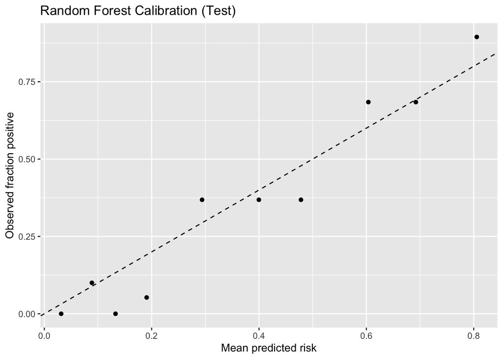

```r
# Calibration
pred_rf_cal <- pred_rf %>% mutate(bin = ntile(.pred_pos, 10)) %>% group_by(bin) %>%
  summarise(mean_pred = mean(.pred_pos), obs = mean(diabetes == "pos"), n = n())

ggplot(pred_rf_cal, aes(x = mean_pred, y = obs)) +
  geom_point() + geom_abline(slope = 1, intercept = 0, linetype = 2) +
  labs(title = "Random Forest Calibration (Test)", x = "Mean predicted risk", y = "Observed fraction positive")
```

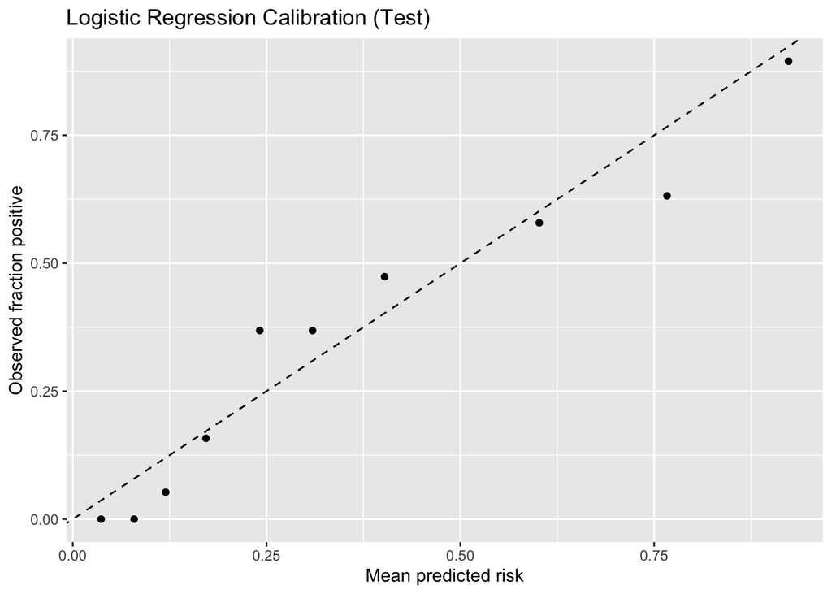

```r
# Calibration (optional, simple reliability plot)
pred_log_cal <- pred_log %>% mutate(bin = ntile(.pred_pos, 10)) %>% group_by(bin) %>%
  summarise(mean_pred = mean(.pred_pos), obs = mean(diabetes == "pos"), n = n())

ggplot(pred_log_cal, aes(x = mean_pred, y = obs)) +
  geom_point() + geom_abline(slope = 1, intercept = 0, linetype = 2) +
  labs(title = "Logistic Regression Calibration (Test)", x = "Mean predicted risk", y = "Observed fraction positive")
```

## 6.1 Estimating predictive SE using boostrapping

```r
set.seed(123)   # for reproducibility
nboot <- 1000   # number of bootstrap replicates
n <- nrow(test)

# Storage for results
auc_log <- acc_log <- numeric(nboot)
auc_rf  <- acc_rf  <- numeric(nboot)

# Begin bootstrap
for (b in 1:nboot) {
  # Get boostrap sample
  idx <- sample(1:n, size = n, replace = TRUE)
  test_b <- test[idx, ]

  # Logistic model predictions
  prob_log <- predict(fit_log, test_b, type = "prob")$.pred_pos
  pred_log <- factor(ifelse(prob_log > 0.5, "pos", "neg"),
                     levels = c("neg", "pos"))

  # Random Forest predictions
  prob_rf <- predict(fit_rf, test_b, type = "prob")$.pred_pos
  pred_rf <- factor(ifelse(prob_rf > 0.5, "pos", "neg"),
                     levels = c("neg", "pos"))

  # --- Logistic model metrics ---
  auc_log[b] <- as.numeric(roc(test_b$diabetes, prob_log, quiet = TRUE)$auc)
  acc_log[b] <- mean(pred_log == test_b$diabetes)

  # --- Random forest metrics ---
  auc_rf[b]  <- as.numeric(roc(test_b$diabetes, prob_rf, quiet = TRUE)$auc)
  acc_rf[b]  <- mean(pred_rf == test_b$diabetes)
}

# Summarize results
summary_stats <- tibble(
  Model = c("Logistic", "Random Forest"),
  AUC_mean = c(mean(auc_log), mean(auc_rf)),
  AUC_se   = c(sd(auc_log), sd(auc_rf)),
  AUC_95CI_lower = c(quantile(auc_log, 0.025), quantile(auc_rf, 0.025)),
  AUC_95CI_upper = c(quantile(auc_log, 0.975), quantile(auc_rf, 0.975)),
  Acc_mean = c(mean(acc_log), mean(acc_rf)),
  Acc_se   = c(sd(acc_log), sd(acc_rf)),
  Acc_95CI_lower = c(quantile(acc_log, 0.025), quantile(acc_rf, 0.025)),
  Acc_95CI_upper = c(quantile(acc_log, 0.975), quantile(acc_rf, 0.975))
)

summary_stats %>% kbl2(digits = 3)
```

| Model | AUC_mean | AUC_se | AUC_95CI_lower | AUC_95CI_upper | Acc_mean | Acc_se | Acc_95CI_lower | Acc_95CI_upper |
| --- | --- | --- | --- | --- | --- | --- | --- | --- |
| Logistic | 0.858 | 0.026 | 0.802 | 0.906 | 0.778 | 0.029 | 0.719 | 0.833 |
| Random Forest | 0.866 | 0.027 | 0.808 | 0.914 | 0.793 | 0.029 | 0.734 | 0.854 |

# 7 Interpretable ML

## 7.1 Variable Importance (Permutation)

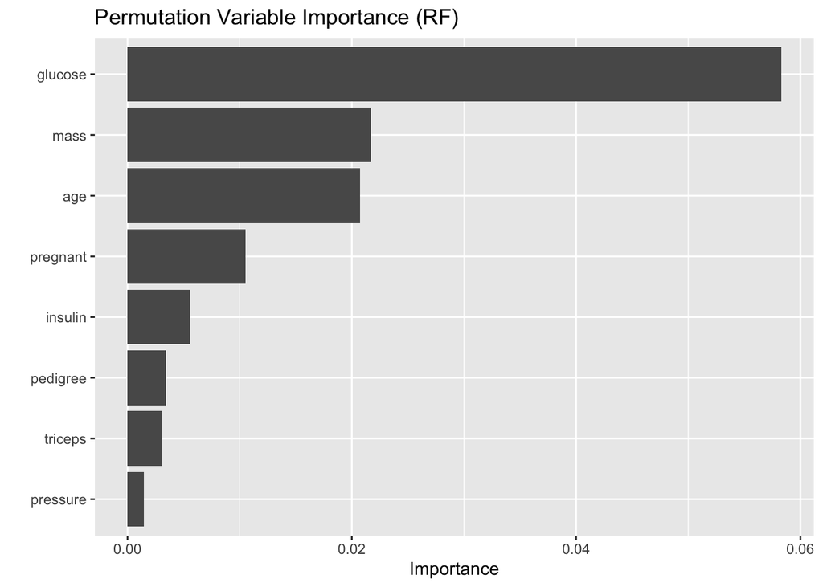

```r
# Extract underlying ranger fit and plot permutation importance
rf_obj <- fit_rf %>% extract_fit_parsnip() %>% pluck("fit")
vip::vip(rf_obj, num_features = 10) +
  labs(title = "Permutation Variable Importance (RF)")
```

## 7.2 Partial Dependence Plots (PDP)

PDP for feature $X_j$: $PD_j(x_j) = \frac{1}{n}\sum_i \hat{f}(x_j, x_{i,-j}).$

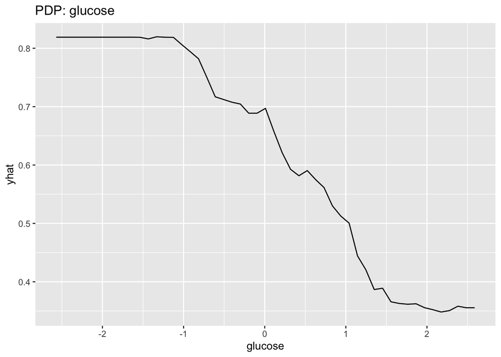

```r
# PDP for key features (example: glucose, mass)
rf_fit <- extract_fit_parsnip(fit_rf)$fit

pdp::partial(
  object   = rf_fit,
  pred.var = "glucose",
  train    = bake(prep_rec, new_data = train) %>% select(-diabetes),
  prob     = TRUE
) %>% autoplot() + ggtitle("PDP: glucose")
```

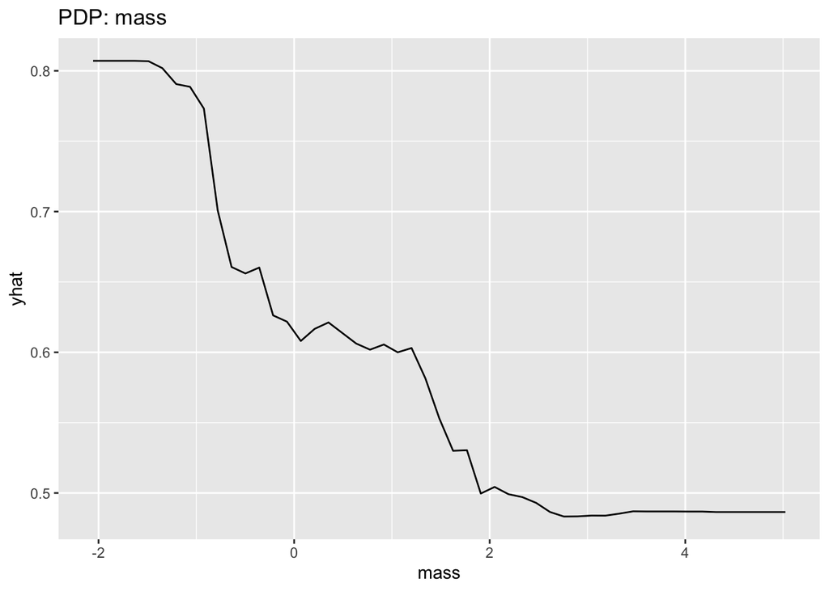

```r
pdp::partial(
  object   = rf_fit,
  pred.var = "mass",
  train    = bake(prep_rec, new_data = train) %>% select(-diabetes),
  prob     = TRUE
) %>% autoplot() + ggtitle("PDP: mass")
```

## 7.3 Accumulated Local Effects (ALE)

ALE is less sensitive than PDP to correlated predictors by aggregating **local** effects.

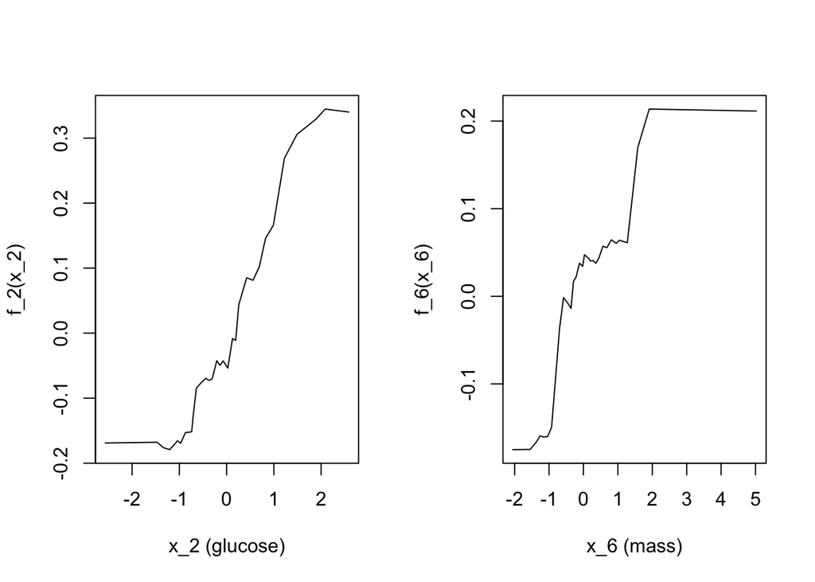

```r
# Extract the underlying ranger model
rf_fit <- extract_fit_parsnip(fit_rf)$fit

# Prepare model matrix and response
train_baked <- bake(prep_rec, new_data = train)
X <- as.data.frame(train_baked %>% select(-diabetes))
y <- train_baked$diabetes

# Define a simple wrapper returning predicted probabilities for the "pos" class
 rf_predict <- function(X.model, newdata) {
   predict(rf_fit, newdata, type = "response")$predictions[, "pos"]
 }

# Compute ALE for glucose
 par(mfrow = c(1,2))
ALE_glu = ALEPlot::ALEPlot(
  X = X,
  X.model = rf_fit,
  pred.fun = rf_predict,
  J = which(names(X) == "glucose"),
  K = 30
  )
ALE_mass = ALEPlot::ALEPlot(
  X = X,
  X.model = rf_fit,
  pred.fun = rf_predict,
  J = which(names(X) == "mass"),
  K = 30
  )
```

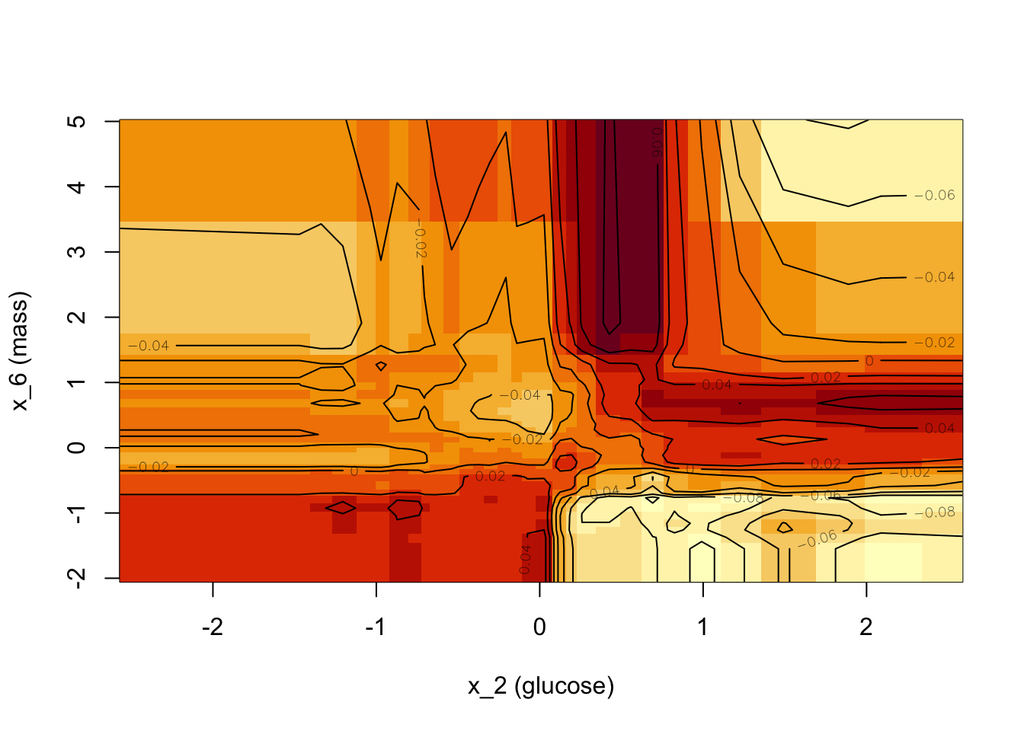

```r
 par(mfrow = c(1,1))
ALE_glumass = ALEPlot::ALEPlot(
  X = X,
  X.model = rf_fit,
  pred.fun = rf_predict,
  J = which(names(X) == "glucose" | names(X) == "mass"),
  K = 30
  )
```

## 7.4 SHAP Values (Local + Global)

SHAP decomposes a prediction into additive feature contributions relative to a baseline.

```r
X_test <- test_baked %>% select(-diabetes)

set.seed(735)
sh_values <- fastshap::explain(
  object        = fit_rf,
  feature_names = names(X_test),
  X             = X_test[1:200, , drop = FALSE],
  pred_wrapper  = rf_predict,
  nsim          = 50
)

# Looking at local importance with SHAP values
X_test[1:200, , drop = FALSE] %>%
  mutate(
    pred = predict(rf_fit, X_test[1:200, , drop = FALSE], type = "response")$predictions[, "pos"]
  ) %>%
  bind_cols(
    as_tibble(sh_values[,1:3]) %>% rename_with(~paste0(.x,"_sh"))
    ) %>%
  # See who has high predictions due to their glucose
  arrange(-glucose_sh) %>%
  head() %>%
  kbl2(digits = 3)
```

| pregnant | glucose | pressure | triceps | insulin | mass | pedigree | age | pred | pregnant_sh | glucose_sh | pressure_sh |
| --- | --- | --- | --- | --- | --- | --- | --- | --- | --- | --- | --- |
| -0.240 | 2.388 | -0.196 | 0.240 | -0.175 | 0.362 | -0.734 | -0.692 | 0.716 | 0.003 | 0.325 | 0.002 |
| -1.124 | 1.523 | -0.035 | 0.009 | -0.175 | -0.014 | 1.200 | -0.282 | 0.845 | -0.005 | 0.315 | 0.024 |
| -0.240 | 1.656 | -0.035 | 0.472 | -0.058 | 0.130 | -0.870 | -0.774 | 0.608 | -0.005 | 0.304 | 0.000 |
| 1.233 | 2.155 | 1.417 | 0.703 | 0.997 | 0.304 | -0.146 | 0.291 | 0.815 | 0.027 | 0.297 | -0.002 |
| -1.124 | 2.554 | -0.519 | 0.356 | 1.572 | 1.289 | 0.110 | -0.446 | 0.790 | -0.001 | 0.293 | 0.016 |
| 0.939 | 2.488 | 1.417 | 0.009 | -0.175 | 1.071 | -0.055 | 0.619 | 0.853 | 0.023 | 0.293 | -0.018 |

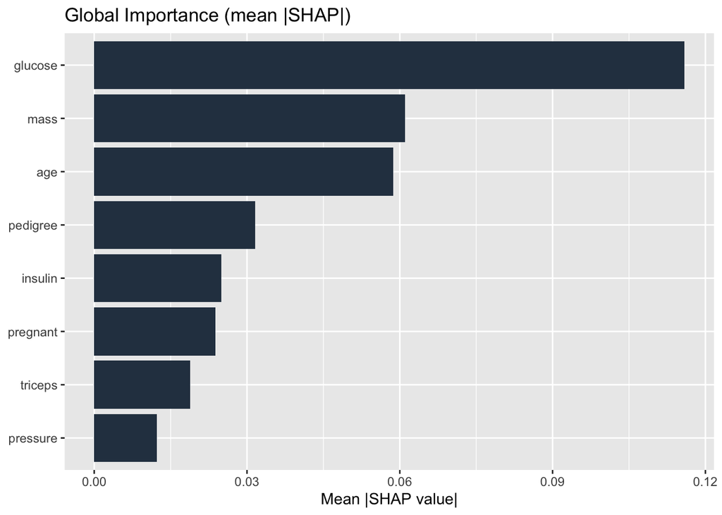

```r
# Compute global importance: mean(|SHAP|)
shap_importance <- data.frame(
  Variable = colnames(sh_values),
  Importance = apply(abs(sh_values), 2, mean)
)

# Sort and visualize
shap_importance <- shap_importance[order(-shap_importance$Importance), ]

ggplot(shap_importance,
       aes(x = reorder(Variable, Importance), y = Importance)) +
  geom_col(fill = "#2C3E50") +
  coord_flip() +
  labs(title = "Global Importance (mean |SHAP|)",
       x = NULL, y = "Mean |SHAP value|")
```

## 7.5 LIME (Local Surrogates)

LIME fits a simple surrogate model in the neighborhood of a single observation to explain a complex model’s prediction.

```r
# Create the explainer using the baked training predictors (as data.frame)
X_train <- as.data.frame(bake(prep_rec, new_data = train) %>% select(-diabetes))

explainer <- lime::lime(
  x = X_train,
  model = rf_fit,              # raw ranger model, not workflow
  bin_continuous = TRUE,
  n_bins = 4
)

explanations <- lime::explain(
  X_test[1:4, , drop = FALSE],
  explainer = explainer,
  n_features = 5,
  n_labels = 1
)

# Pick one test observation to explore
i <- 3

# Filter LIME results for that specific individual
lime_i <- explanations %>%
  filter(case == unique(case)[i]) %>%
  arrange(desc(feature_weight))

# Print numeric summary table
lime_i %>%
  select(feature, feature_value, feature_weight, feature_desc, model_r2,label, label_prob) %>%
  kbl2(digits = 3)
```

| feature | feature_value | feature_weight | feature_desc | model_r2 | label | label_prob |
| --- | --- | --- | --- | --- | --- | --- |
| glucose | 2.521 | 0.223 | 0.591 < glucose | 0.418 | pos | 0.687 |
| insulin | 4.726 | 0.078 | -0.175 < insulin | 0.418 | pos | 0.687 |
| age | 1.603 | 0.045 | 0.619 < age | 0.418 | pos | 0.687 |
| triceps | 1.861 | 0.030 | 0.35598 < triceps | 0.418 | pos | 0.687 |
| pedigree | -1.003 | -0.033 | pedigree <= -0.715 | 0.418 | pos | 0.687 |

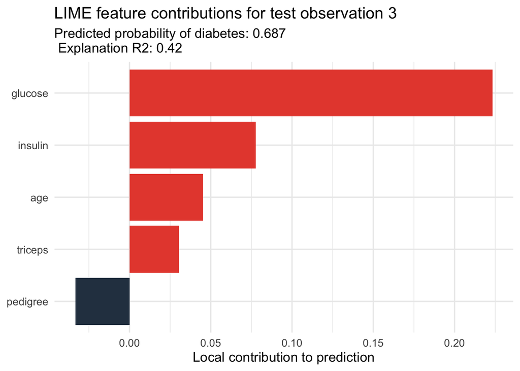

```r
# Plot bar chart of contributions
ggplot(lime_i, aes(x = reorder(feature, feature_weight),
                   y = feature_weight,
                   fill = feature_weight > 0)) +
  geom_col(show.legend = FALSE) +
  coord_flip() +
  labs(
    title = paste("LIME feature contributions for test observation", i),
    subtitle = paste0("Predicted probability of diabetes: ",
                      round(unique(lime_i$label_prob), 3),"\n Explanation R2: ", round(lime_i$model_r2[1],2)),
    x = NULL,
    y = "Local contribution to prediction"
  ) +
  scale_fill_manual(values = c("#2C3E50", "#E74C3C")) +
  theme_minimal(base_size = 13)
```

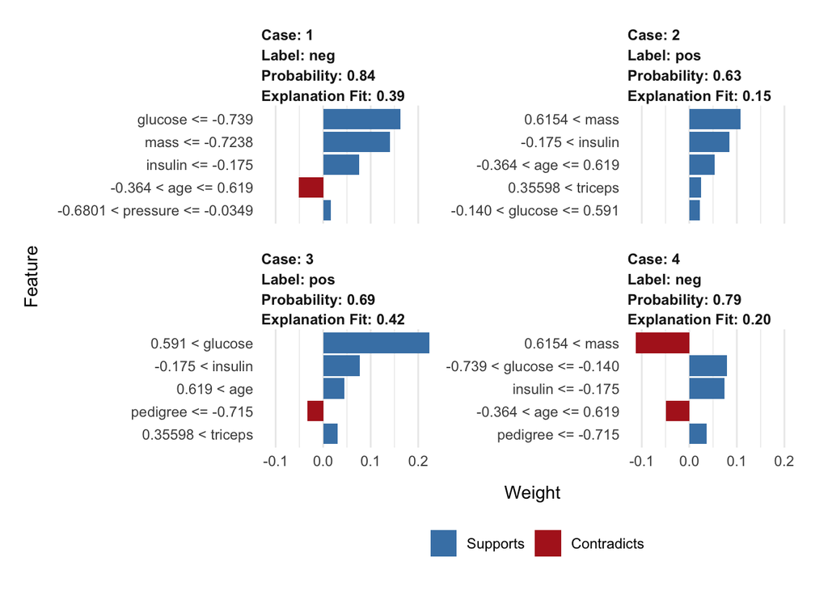

```r
plot_features(explanations)
```

```r
tibble(X_test[1:4,], pred = rf_predict(rf_fit, test_baked[1:4,])) %>% kbl2(digits = 3)
```

| pregnant | glucose | pressure | triceps | insulin | mass | pedigree | age | pred |
| --- | --- | --- | --- | --- | --- | --- | --- | --- |
| -0.829 | -1.205 | -0.519 | 0.009 | -0.175 | -0.840 | -0.378 | -0.200 | 0.157 |
| -1.124 | 0.525 | -2.616 | 0.703 | 0.329 | 1.549 | 5.888 | -0.036 | 0.634 |
| -0.534 | 2.521 | -0.196 | 1.861 | 4.726 | -0.275 | -1.003 | 1.603 | 0.687 |
| 0.055 | -0.373 | 1.578 | 0.009 | -0.175 | 0.753 | -0.896 | -0.282 | 0.206 |

# 8 Reporting Tips

- Document how you chose features to visualize (e.g., top-5 by permutation importance).
- **Acknowledge assumptions/limitations:** PDP assumes weak dependence; ALE mitigates this but is still an approximation. LIME is *explanatory*, not causal — it shows which features the model relied on, not which features cause the outcome.
- **Quantify uncertainty where possible:** re-run interpretability summaries over resamples to assess stability.
- **Communicate clearly:** convert technical findings to public-health implications (modifiable risks, thresholds, nonlinearity).